# Astronomical Applications of PCA

## PCA - projecting the data onto a set of orthogonal uncorrelated axes

The observations themselves are already a set of orthogonal bases, the power of PCA is to project the data onto a set of new axes which are aligned with the direction of *maximum variance*.

### Steps of PCA (a.k.a Karhunen–Loève or Hotelling)

1. Pre-process your data (subtract the means, divide by the variances in each dimension, normalize spectra)
   - if the mean is not subracted, the first principal component will denote the mean value, and the second and further components will denote variances (Brunt & Heyer 2002)
2. Implement PCA, i.e. sklearn.decomposition.PCA:
   - initialize PCA class
   - apply to data matrix
   - identify principle and higher order components (maximize variance)

### Many built-in algorithms for doing the actual decomposition:

- To compute bases from eigenvalues of the covariance matrix: np.linalg.eigh, scipy.linalg.eigh
- To compute bases from SVD: numpy.linalg.svd
- To have the algorithm do it all for you: scikitlearn.decomposition.PCA (uses SVD)

*** Note: linalg.eigh returns eigenvalues in increasing order, you must reorder the returned evals/evecs matricies in decreasing order

# SDSS spectra

Let's start with a sample of galaxy spectra from SDSS. This is a plot of 15 sample galaxies, each has been normalized

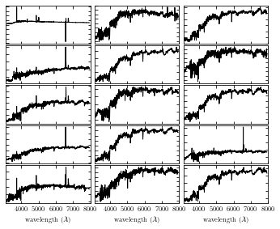

```python
plot()
```

### Example determining the first 4 eigenspectra of a sample of 2000 SDSS spectra:

Retrieve 2000 random galaxy spectra from SDSS, and use them to compute the mean and first 4 eigenspectra

```
Eigenvalues: [0.8893158  0.06058301 0.02481432 0.01012148]
```

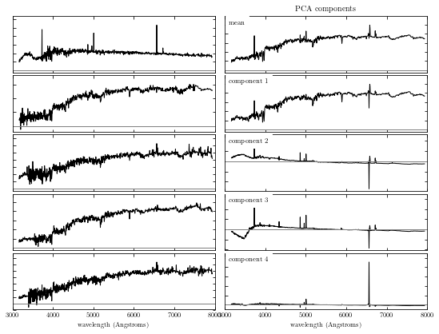

```python
plot()
```

### You can reconstruct any science spectrum using a combination of N eigenspectra

In this example, we reconstruct a particular spectrum from its eigenspectra. The input spectrum is shown in grey, and the reconstructed spectrum is shown in black. By the time we've built up using 20 components, 94% of the variance is modeled, and the reconstruction if very close to the input.

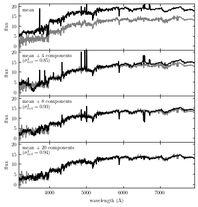

```python
plot()
```

### Scree plot: ~93% of the information is contained within the first 10 eigenspectra:

This is a scree plot of the eigenvalues of the previous example:

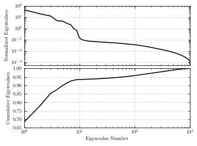

```python
plot()
```

# Imaging

A set of reference images can be used to form a basis set of eigenimages. Each eigenimage is an orthogonal direction from which the images differ from the the mean image. Then, a linear combination of these eigenimages can be formed that reconstructs a given target image by projecting the target image onto the basis set. If a set of M refrence images is used to construct N $\le$ M eigenimages, then a target image can be reconstructed using appropriately weighted K eigenimages. image1 = (23% of E1) + (2% of E2) + (51% of E3) + ... + (1% En). Dimensionality reduction is acheived in that K $\lt$ N.

This is how your phone recognizes your face! The set of eigenimages is produced by performing PCA on a large set of images.

Steps for using PCA in imaging:

- Prepare a set of reference images to construct the basis set. Each image should be same size and resolution, and aligned. Concatenate each reference image into a single vector.
  - Ex: If you have a training set of T = rxmxn images, turn them into T = rxp array where p = mxn. np.reshape() function works well for this.
- Subtract the mean from each reference image
- Perform pca on the covariance matix of T to get the eigenvalues and eigenvectors (eigenimages)
- Sort eigenvalues in decending order
- Determine the number of principle components, k, desired to use in reconstruction
- Project the target image onto the basis set

> [PCA on astronomical images, including the math: Soummer+ 2012](https://iopscience.iop.org/article/10.1088/2041-8205/755/2/L28/pdf)

### PCA on imaging is used in PSF subtraction: RDI

Reference differential imaging (RDI): Build a set of eigenimages from PSF reference stars, construct a model PSF of your science target, and subtract the star's PSF model from the image to reveal faint planets/disks.

My science is called BDI: Binary Differential Imaging. In binaries where both stars fit on the detector (in the same isoplanatic angle of the AO system) but are far enough apart to be well resolved, we can use the PSF of one star as a set of reference images for the other, and vice versa. The advantage is that the reference star and science target are imaged at the same time and in the same conditions, so it should provide a superior set of reference images for modeling the science target's stellar flux using PCA, comapred to reference stars not imaged simultaneously.

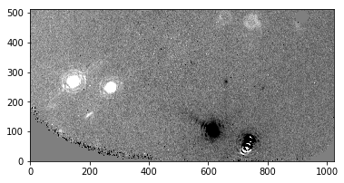

```python
from astropy.io import fits
from astropy.visualization import ZScaleInterval, ImageNormalize

image = fits.getdata('lecture11_files/BDI0933__00001.fit')

%matplotlib inline
plt.imshow(image,origin='lower',cmap='gray',norm = ImageNormalize(image, interval=ZScaleInterval(),))
plt.show()
```

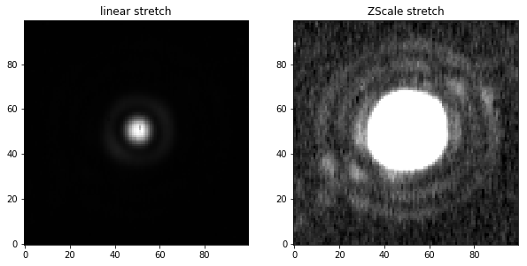

```python
# Cut out just the interested star A as the science target:
x,y = 147, 268
science_target = image[np.int_(y-50):np.int_(y+50),np.int_(x-50):np.int_(x+50)]

plt.figure(figsize=(10,5))
# Linear stretch:
plt.subplot(121)
plt.imshow(science_target,origin='lower',cmap='gray')
plt.title('linear stretch')
# ZScale stretch:
plt.subplot(122)
plt.imshow(science_target,origin='lower',cmap='gray',norm = ImageNormalize(science_target, interval=ZScaleInterval(),))
plt.title('ZScale stretch')
plt.show()
```

My homebrewed PCA algorithm produced these eigenimages using all frames of star B:

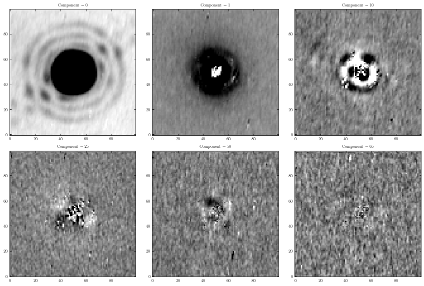

```python
plot()
```

Scree plot for these eigenimages:

[figure not shown]

And the final subtracted image using 10 components (also derotated; this is a work in progress, and more work needs to be done to subtract the starlight better than this!)

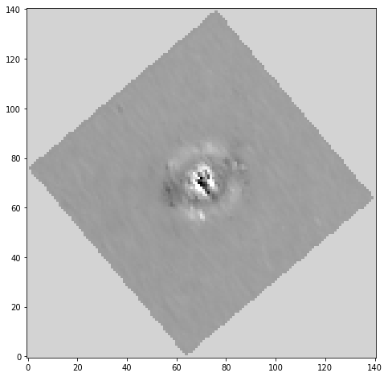

```python
psfsub = fits.getdata('lecture11_files/psfsub.fits')

plt.figure(figsize = (8,8))
plt.imshow(psfsub, origin='lower',cmap='gray',\
           norm = ImageNormalize(psfsub, interval=ZScaleInterval(),))
plt.show()
```

### How many eigenimages to use?

Dilema: fully subtract the starlight without subtracting any planet signal.  
Trade off:

- too few modes = insufficient starlight subtraction
- too many modes = subtracting flux from the faint planet Each image and science case is different and requires fine-tuning.

The Gemini Planet Imager (GPI) team recommends 20-50 modes for planets, 1-10 modes for disks (but that's specific to their instrument!)

Example: GPI image of Beta Pic b:

Image source: pyKLIP documentation, GPI team.

> https://pyklip.readthedocs.io/

[figure not shown]